# INF-612 Handling Data

Paulo Sigrist / Rafael Sangalli

October 7, 2015

# Carregando os dados:

O primeiro passo é carregar os dados no formato CSV. Nesse processo, o período já é filtrado para o período desejado:

```r
cpa = loadAndFilterData()
```

Abaixo, o resultado com os primeiros registros:

|  | horario | temperatura | vento | umidade | sensacao |
| --- | --- | --- | --- | --- | --- |
| 16313 | 2014-07-01 00:00:00 | 12.7 | 15.2 | 73.6 | 8.0 |
| 16314 | 2014-07-01 00:10:00 | 12.6 | 13.7 | 73.6 | 8.2 |
| 16315 | 2014-07-01 00:20:00 | 12.5 | 12.9 | 74.0 | 8.2 |
| 16316 | 2014-07-01 00:30:00 | 12.6 | 11.3 | 73.7 | 8.6 |
| 16317 | 2014-07-01 00:40:00 | 12.8 | 6.3 | 72.7 | 9.7 |
| 16318 | 2014-07-01 00:50:00 | 13.4 | 7.0 | 70.5 | 10.2 |

E agora os últimos registros:

|  | horario | temperatura | vento | umidade | sensacao |
| --- | --- | --- | --- | --- | --- |
| 68013 | 2015-06-30 23:00:00 | 17.7 | 20.7 | 81.7 | 16.2 |
| 68014 | 2015-06-30 23:10:00 | 17.5 | 17.8 | 82.4 | 16.0 |
| 68015 | 2015-06-30 23:20:00 | 17.4 | 16.2 | 82.6 | 15.9 |
| 68016 | 2015-06-30 23:30:00 | 17.1 | 16.7 | 83.6 | 15.5 |
| 68017 | 2015-06-30 23:40:00 | 17.2 | 17.3 | 83.0 | 15.7 |
| 68018 | 2015-06-30 23:50:00 | 17.2 | 17.9 | 83.4 | 15.6 |

# Análises:

Após a obteção dos dados, fizemos as seguintes análises:

- Média de temperatura por mês
- Comparadação da evolução da temperatura por dia a cada mês
- Histograma das medidas por estação do ano

## Média de temperatura por mes:

```
## function (cpa)
## {
##     r <- tapply(cpa[["temperatura"]], cpa[["horario"]]$mon, mean,
##         na.rm = TRUE)
##     rownames(r) <- month.name
##     barplot(r, col = colors()[1:12], main = "Media de temperatura por mes",
##         xlab = "Meses", ylab = "Temperatura")
## }
```

Podemos observar nesse gráfico que a temperatura cai por volta de 5 graus nos meses de inverno.

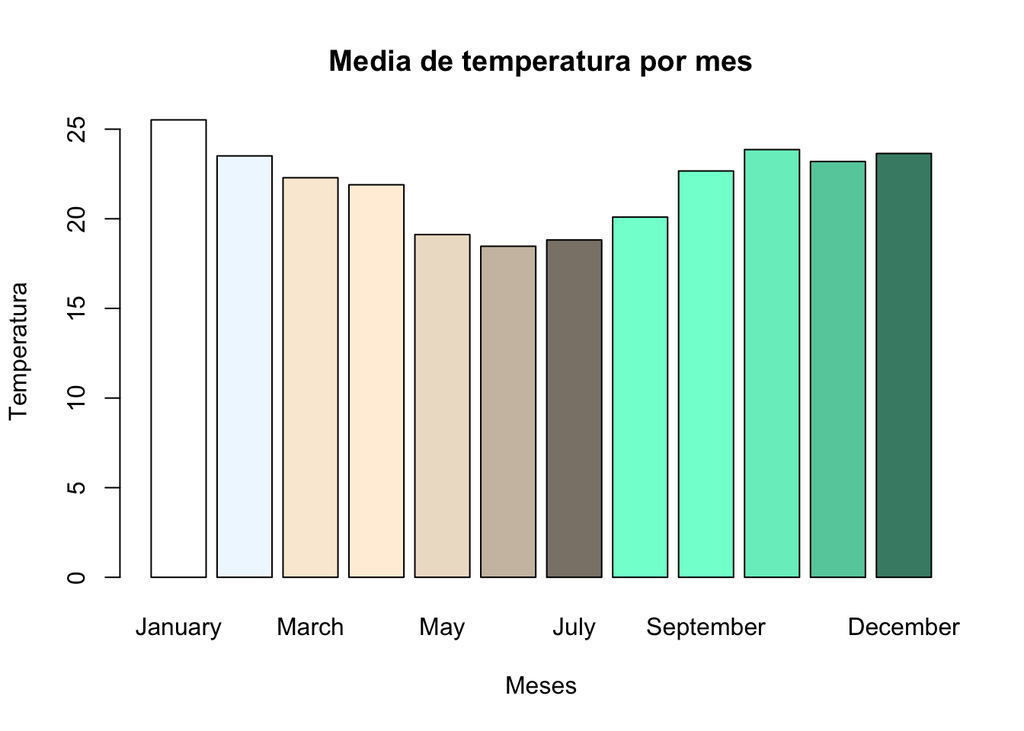

## Evolução da temperatura dia após dia:

Nessa análise, podemos observar a evolução da temperatura por dia, a cada mês.

Para efetuar esse cálculo, foram criadas duas funções auxiliares, `dataByMonth` e `meanByDay`. A primeira irá retornar somente dados do `cpa` do mês especificado. A segunda irá calcular a média da temperatura por dia. Abaixo o código das duas funções:

```r
dataByMonth
```

```
## function (m, cpa)
## {
##     cpa[cpa$horario$mon == m, ]
## }
```

```r
meanByDay
```

```
## function (month, cpa)
## {
##     x <- dataByMonth(month, cpa)
##     tapply(x[["temperatura"]], x[["horario"]]$mday, mean, na.rm = TRUE)
## }
```

Agora podendo calcular a média de temperatura por dia para cada mês, temos que aplicar isso no nosso data frame `cpa`. Para isso, criamos um array de 0 até 11 e com a função `sapply` calculamos o resultado.

Plotamos um gráfico e depois novamente utilizando a função `sapply` adicionamos as linhas dos resultados no gráfico. Abaixo o código fonte da função:

```r
temperatureByDay
```

```
## function (cpa)
## {
##     r <- sapply(c(0:11), meanByDay, cpa)
##     cores <- c("red", "blue", "green", "yellow", "brown", "purple",
##         "yellowgreen", "orange", "magenta", "pink", "navy", "black")
##     plot(c(10:32), type = "n", main = "Alteracao de temperatura por dia",
##         xlab = "Dias", ylab = "Graus (em Celsius)")
##     sapply(c(1:12), function(l) {
##         lines(unlist(r[l]), col = cores[l])
##     })
##     legend("bottomleft", month.name, col = cores, pch = 15, cex = 0.75)
## }
```

O resultado final é o gráfico abaixo:

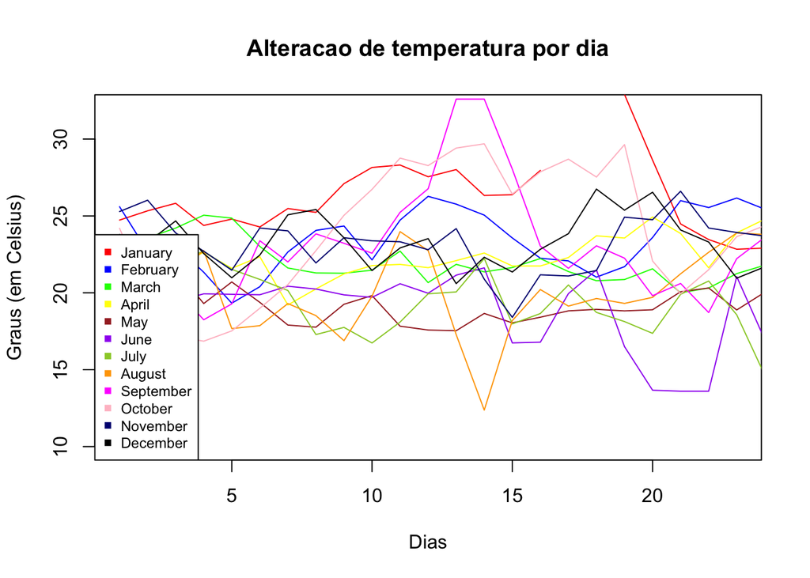

## Histogramas por estação do ano:

Nessa análise, plotamos um historiograma para cada medida obtida (temperatura, sensação, vento e umidade) para cada estação do ano. Para agrupar os dados por estação, foi criada uma função chamada `dataBySeason` onde criamos uma estrutura que contém os dados agrupados pelas quatro estações do ano. Abaixo está o código da função:

```r
dataBySeason
```

```
## function (cpa)
## {
##     inverno <- dataByInterval("2014-06-21 00:00:00", "2014-09-21 23:59:59",
##         cpa)
##     primavera <- dataByInterval("2014-09-22 00:00:00", "2014-12-20 23:59:59",
##         cpa)
##     verao <- dataByInterval("2014-12-22 00:00:00", "2015-03-19 23:59:59",
##         cpa)
##     outono <- dataByInterval("2015-03-20 00:00:00", "2015-06-20 23:59:59",
##         cpa)
##     inverno2 <- dataByInterval("2015-06-21 00:00:00", "2015-09-21 23:59:59",
##         cpa)
##     inverno <- rbind(inverno, inverno2)
##     m <- 0
##     m$inverno <- inverno
##     m$primavera <- primavera
##     m$verao <- verao
##     m$outono <- outono
##     return(m)
## }
```

Foi criada uma função genérica para plotar um historiograma de um array de dados, onde passamos alguns valores, como o array de dados, título do gráfico, label do eixo X e cores do gráfico. Abaixo está o código da função `histogramByValue`:

```r
histogramByValue
```

```
## function (data, title, xlabel = title, col1 = "rosybrown", col2 = "blue")
## {
##     h <- hist(data, main = title, xlab = xlabel, ylab = "Ocorrencias",
##         col = col1)
##     xfit <- seq(min(data, na.rm = TRUE), max(data, na.rm = TRUE),
##         length = 100)
##     yfit <- dnorm(xfit, mean = mean(data, na.rm = TRUE), sd = sd(data,
##         na.rm = TRUE))
##     yfit <- yfit * diff(h$mids[1:2]) * length(data)
##     lines(xfit, yfit, col = col2, lwd = 3)
## }
```

Com essas duas funções, podemos agora os histogramas para análise

### Inverno

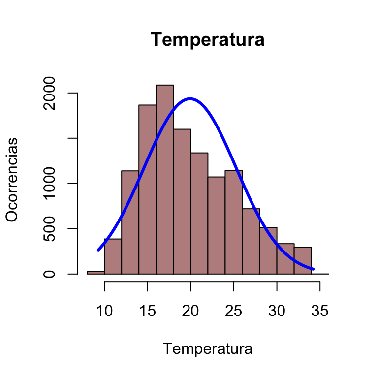

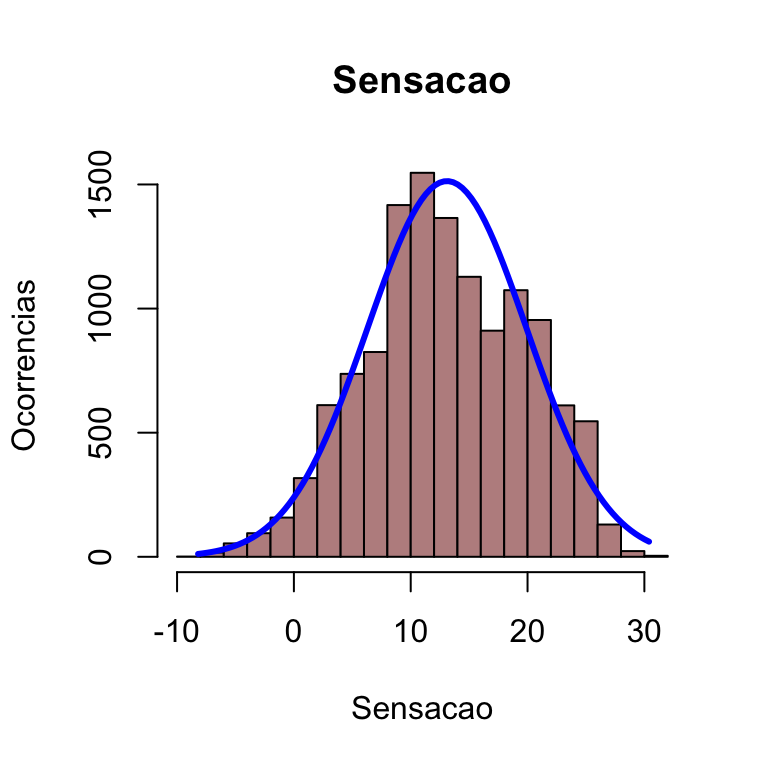

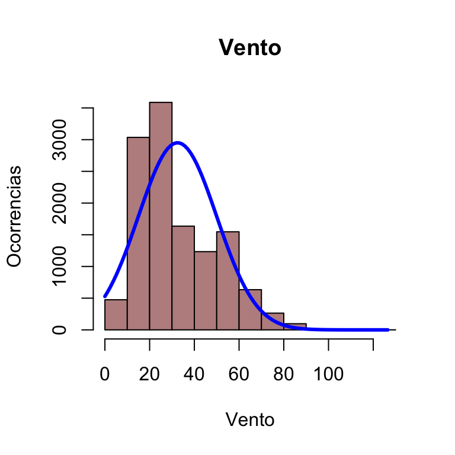

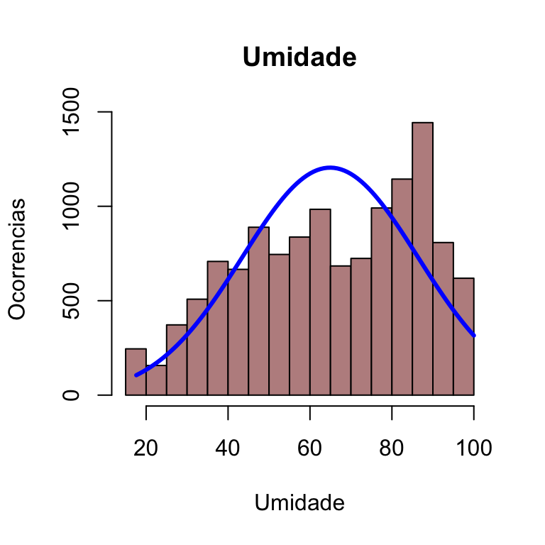

Podemos observar que no inverno, a temperatura se concentrou entre 15 e 20 graus e a sensação ficou um pouco abaixo, entre 10 e 15 graus e tivemos uma umidade alta.

### Primavera

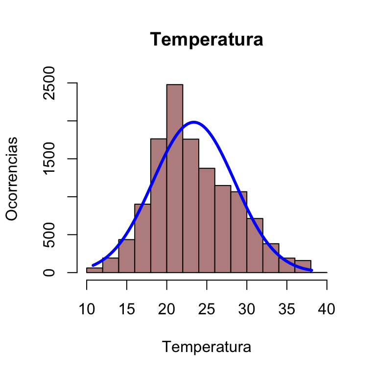

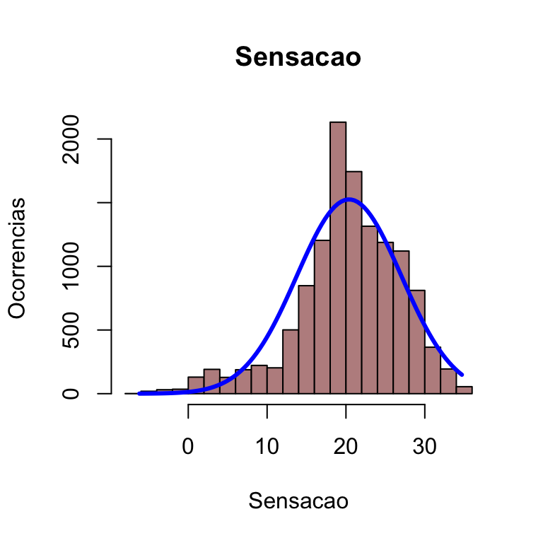

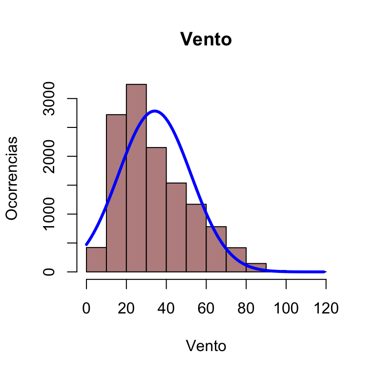

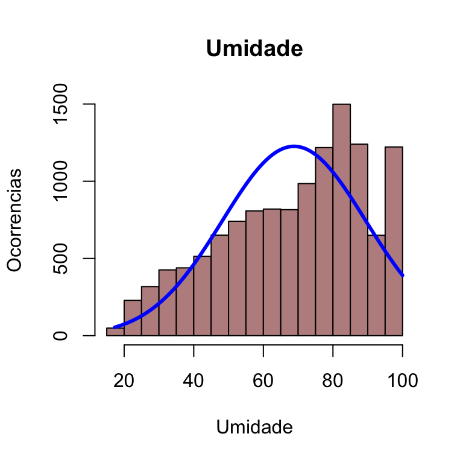

Já na primavera, a temperatura foi mais elevada, ficando entre 20 e 25 graus por mais vezes. Já a sensação ficou entre 18 e 23 graus.

### Verão

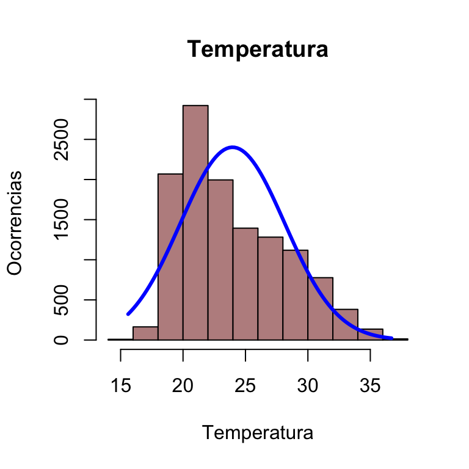

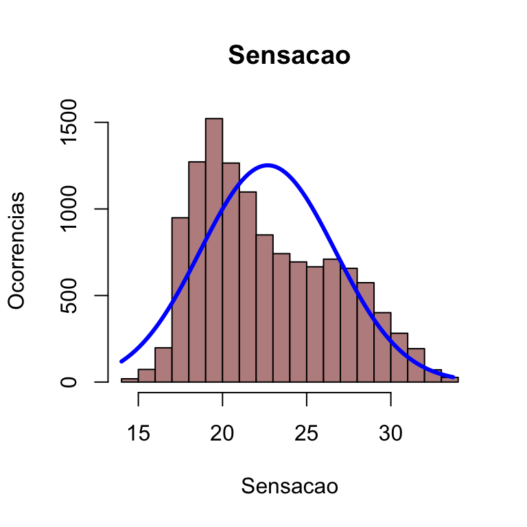

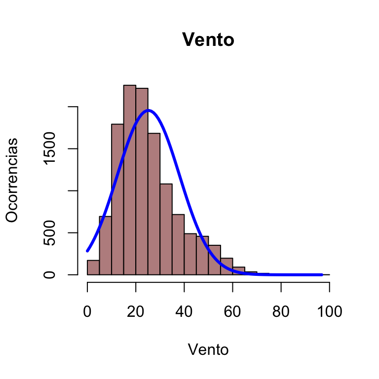

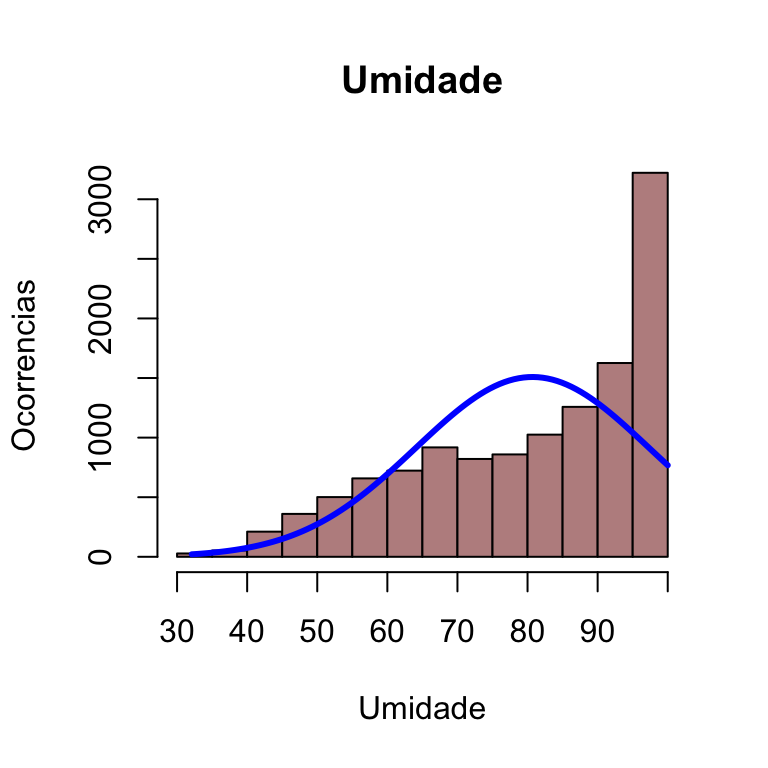

### Outono

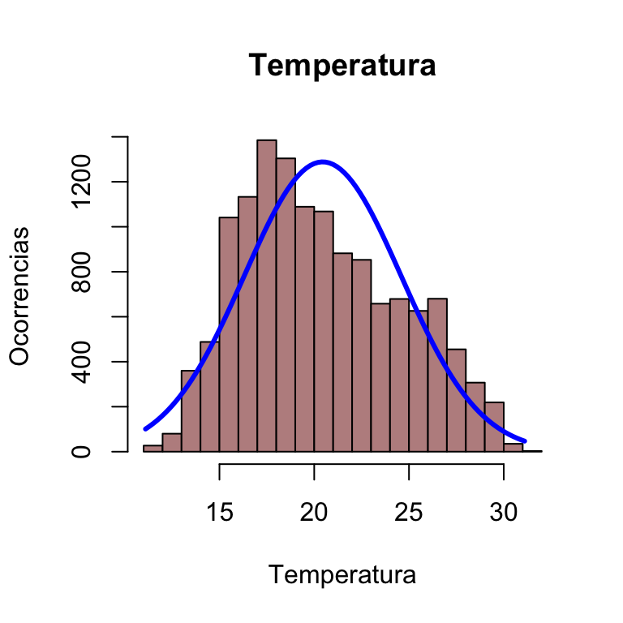

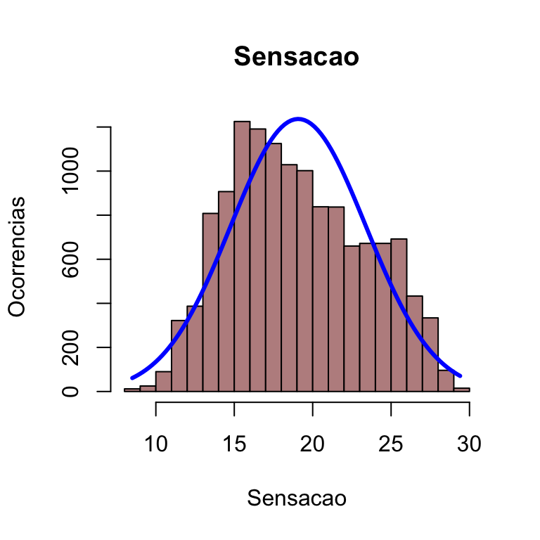

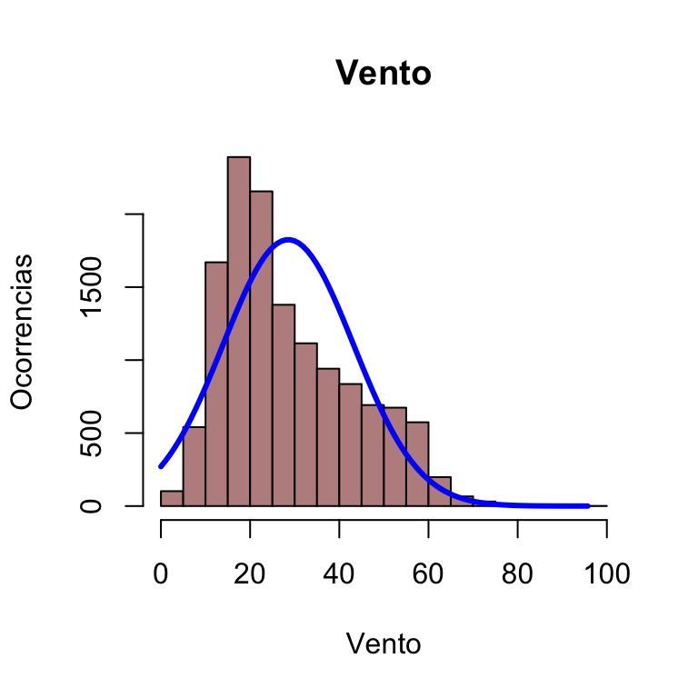

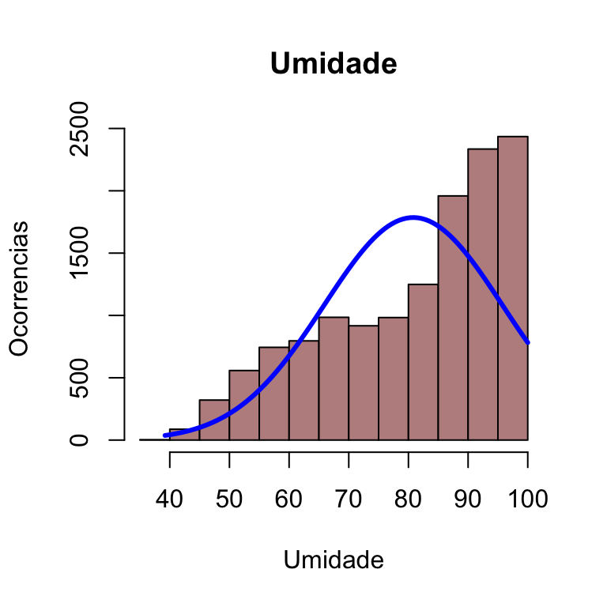

No outono já tivemos temperaturas mais baixas, concentrando sua variação entre 15 e 22 graus e uma umidade bem alta.